# Angola COVID-19 Analysis

# 1. Introduction

Angola is a large Southern African nation whose varied terrain encompasses tropical Atlantic beaches, a labyrinthine system of rivers and Sub-Saharan desert that extends across the border into Namibia. The COVID-19 pandemic in Angola is part of the worldwide pandemic of coronavirus disease 2019 (COVID-19) caused by severe acute respiratory syndrome coronavirus 2 (SARS-CoV-2). The virus was confirmed to have spread to Angola in late March 2020, with the first two cases being confirmed on 21 March.

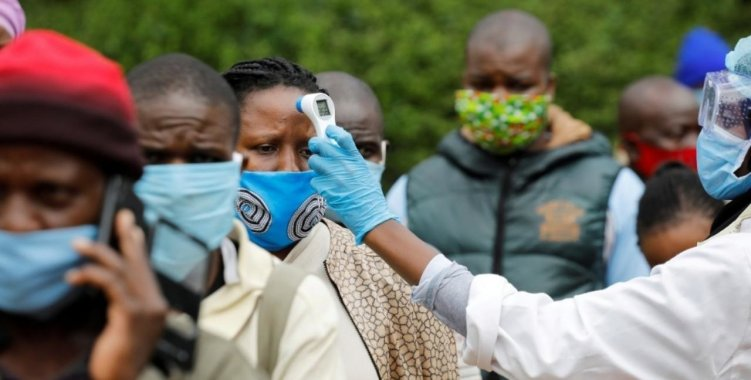

## Visualization of the location

Angola is located on the western Atlantic Coast of Central Africa between Namibia and the Republic of the Congo. It also is bordered by the Democratic Republic of the Congo and Zambia to the east. The country consists of a sparsely watered and somewhat sterile coastal plain extending inland for a distance varying from 50 to 160 km (31 to 99 mi). Slightly inland and parallel to the coast is a belt of hills and mountains and behind those a large plateau. The total land size is 1,246,700 km2 (481,400 sq mi). It has an Exclusive Economic Zone of 518,433 km2 (200,168 sq mi).

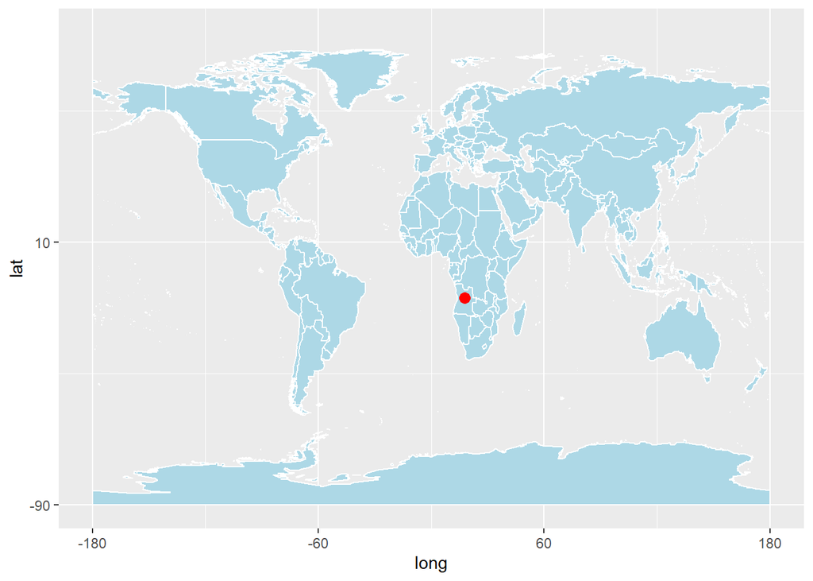

**Figure 01 : Location of Angola in World map**

## Climate Condition

Like the rest of tropical Africa, Angola experiences distinct, alternating rainy and dry seasons. The coastal strip is tempered by the cool Benguela Current, resulting in a climate similar to coastal Peru or Baja California. It is semiarid in the South and along the coast to Luanda. There are two rainy seasons in the steppe; the short rains from November to February, and the high rains from March and April. Summers are hot and humid, while winters are mild and dry. The north has a cool, dry season. The climate is greatly influenced by the prevailing winds, which arc W., S.W. and S.S.W. Two seasons are distinguished – the cool, from June to September; and the rainy, from November to April. The heaviest rainfall occurs in April, and is accompanied by violent storms. The far north and Cabinda have the highest annual rainfall.

## Lockdown status of the country

Angola reimposed movement restrictions and increased fines for people flouting measures to limit a second wave of Covid-19 infections. Government offices will operate with only 50% of staff, while the private sector will be allowed 75%, Minister of State Adao de Almeida told reporters in the capital, Luanda, on Wednesday. Home gatherings will be restricted to 15 people and a 10 p.m. to 5 a.m. curfew introduced. Angola: Authorities lift COVID-19 lockdown in Luanda Sept. 1

## Actions taken by the government

**1.The majority of COVID-19 cases are in the capital city of Luanda, but COVID-19 has been confirmed throughout the provinces. Officials continue to monitor the individuals who have tested positive.**

**2.The use of a face mask is required in all public areas, including anytime you leave your house or hotel room, while using public transport, and in all establishments. Face masks are not required if you are operating a vehicle alone or exercising outside.**

**3.In the city of Luanda, individual and group exercise is permitted between the hours of 5 a.m. to 8 p.m.**

**4.Groups exercising together are limited to no more than five people.Everyone is encouraged to adhere to social distancing.**

**5.Within Luanda, health centers and hospitals are fully operational. Restaurants can be open Monday to Friday from 6:00 a.m. to 10 p.m. In person dining is limited to 50 percent capacity with no more than four guests per table. Stores, including supermarkets, can remain open until 8:00 p.m.**

**6.Museums and monuments, libraries, and media centers must close by 6 p.m.; cultural and art fairs by 8 p.m.**

**7.movie theaters by 10 p.m., and all are limited to 50 percent capacity. Night clubs remain closed. Religious activities are limited to 50 percent capacity up to a maximum of 100 people with a maximum duration of two hours if held in enclosed spaces.**

**8.Beaches and public swimming pools will reopen for recreational use on September 15. Recreational use of boats is permitted, up to 50 percent of capacity.**

# 2.Explotary Data Analysis

## Visualization of death, confirmed,recovered and active cases

## Summary

```
##       date              province           country               lat
##  Min.   :2020-01-22   Length:1818        Length:1818        Min.   :-11.2
##  1st Qu.:2020-06-21   Class :character   Class :character   1st Qu.:-11.2
##  Median :2020-11-19   Mode  :character   Mode  :character   Median :-11.2
##  Mean   :2020-11-19                                         Mean   :-11.2
##  3rd Qu.:2021-04-20                                         3rd Qu.:-11.2
##  Max.   :2021-09-18                                         Max.   :-11.2
##
##       long           type               cases
##  Min.   :17.87   Length:1818        Min.   :-307.00
##  1st Qu.:17.87   Class :character   1st Qu.:   0.00
##  Median :17.87   Mode  :character   Median :   5.00
##  Mean   :17.87                      Mean   :  52.61
##  3rd Qu.:17.87                      3rd Qu.:  69.00
##  Max.   :17.87                      Max.   :1029.00
##                                     NA's   :45
```

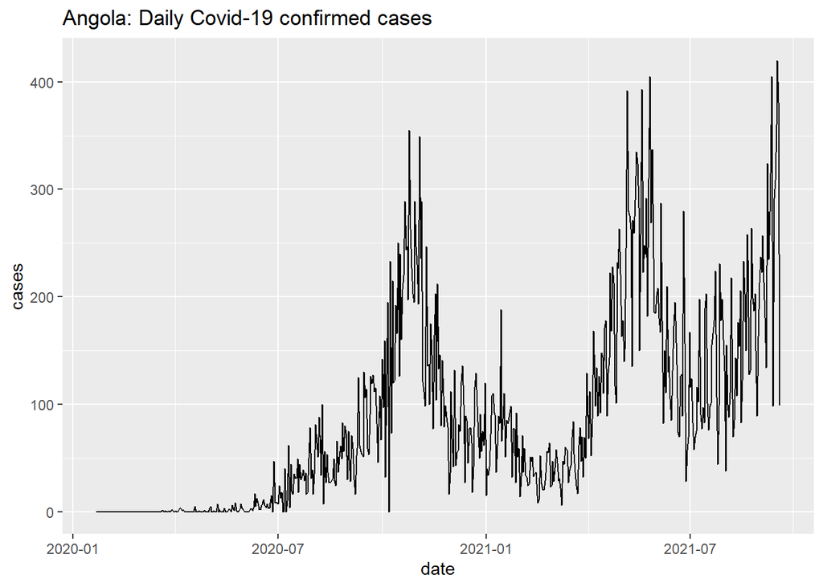

**Figure 02 : Daily Covid-19 confirmed cases in Angola**

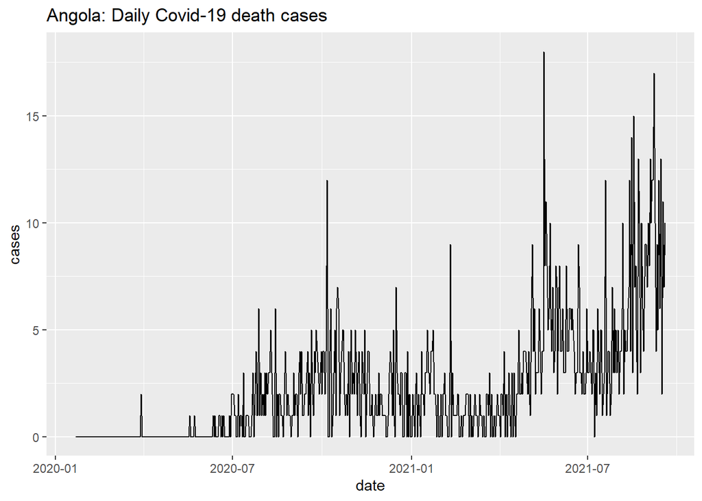

**Figure 03 : Daily Covid-19 death cases in Angola**

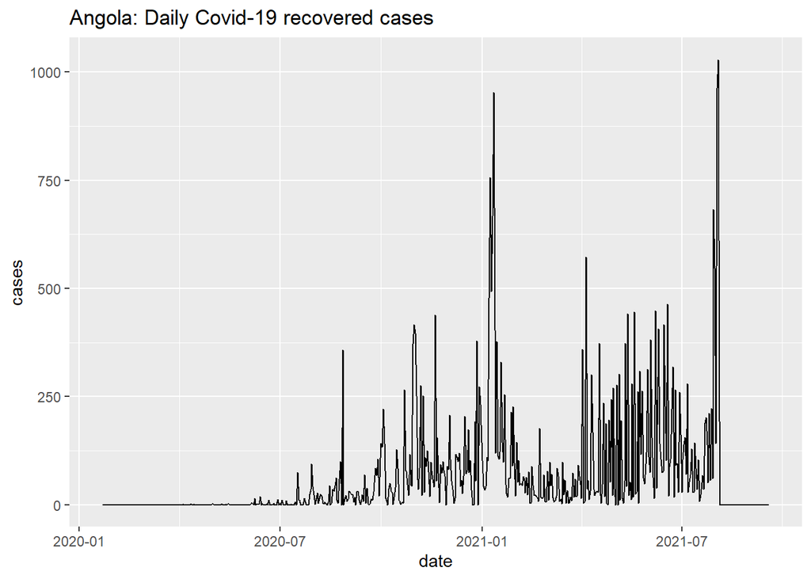

**Figure 04 : Daily Covid-19 recovered cases in Angola**

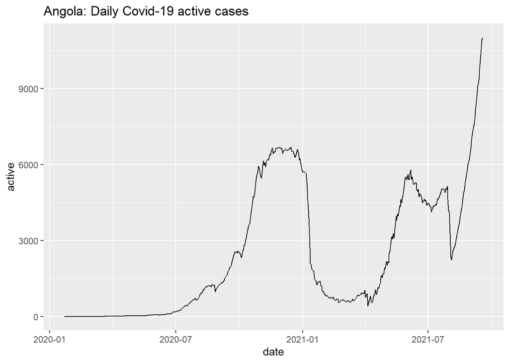

**Figure 05 : Daily Covid-19 active cases in Angola**

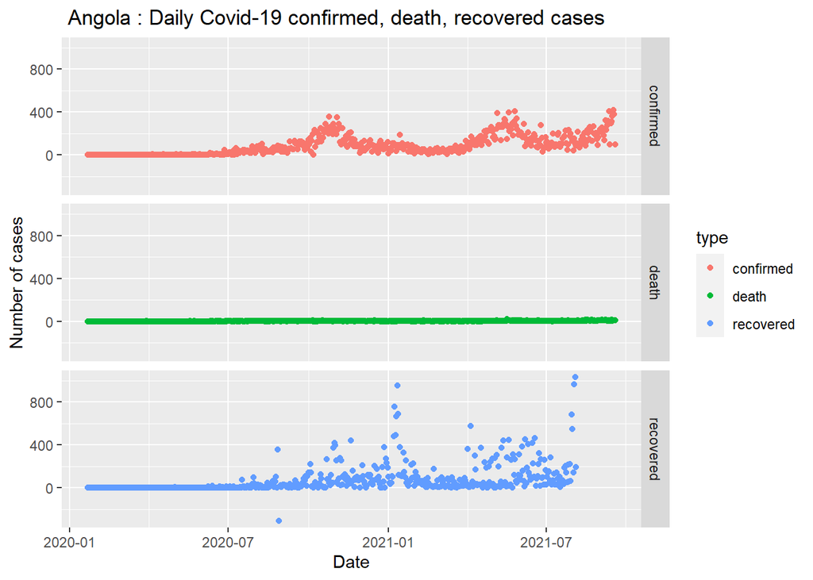

**Figure 06 : Daily Covid-19 confirmed, death, recovered cases in Angola**

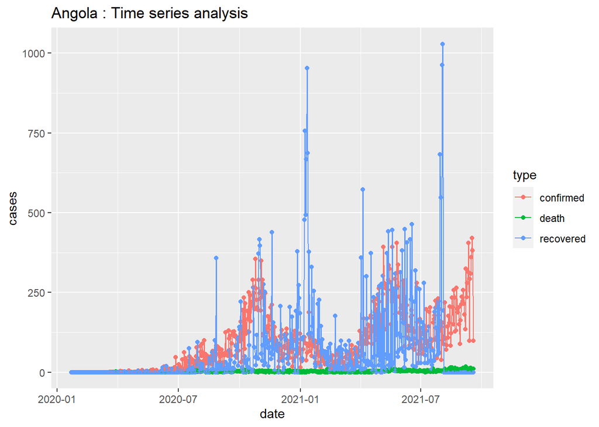

**Figure 07 : Daily Covid-19 confirmed, death, recovered cases in Angola**

## Comparison with other countries

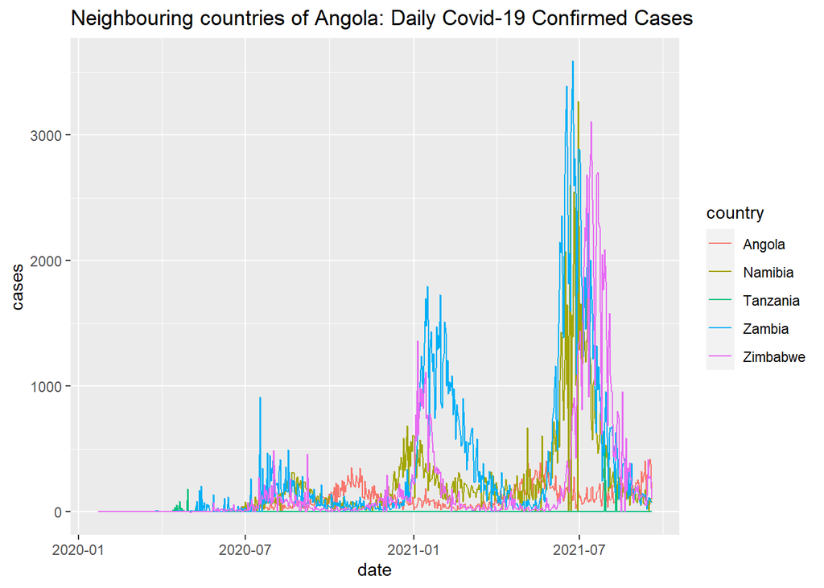

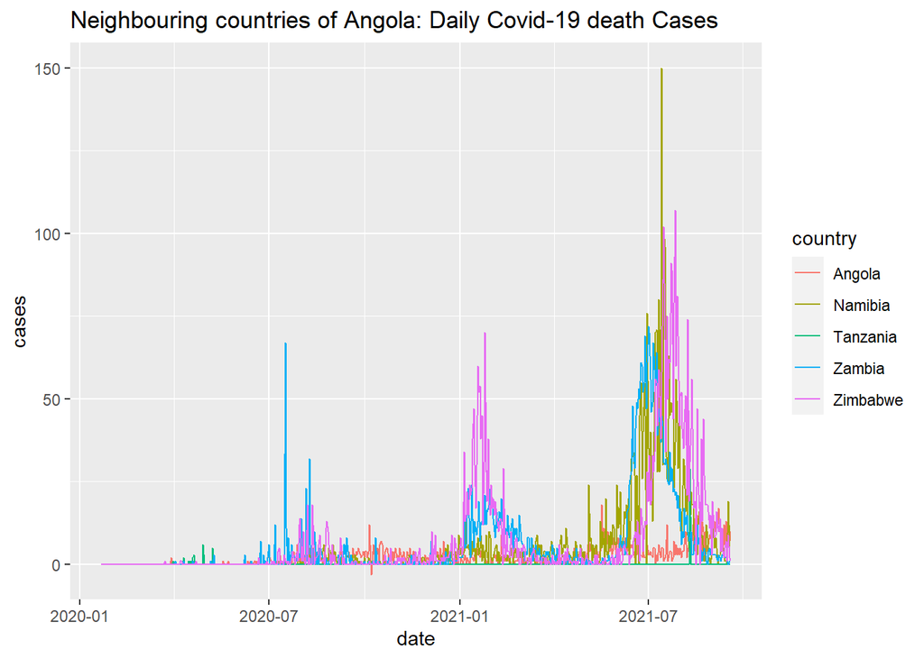

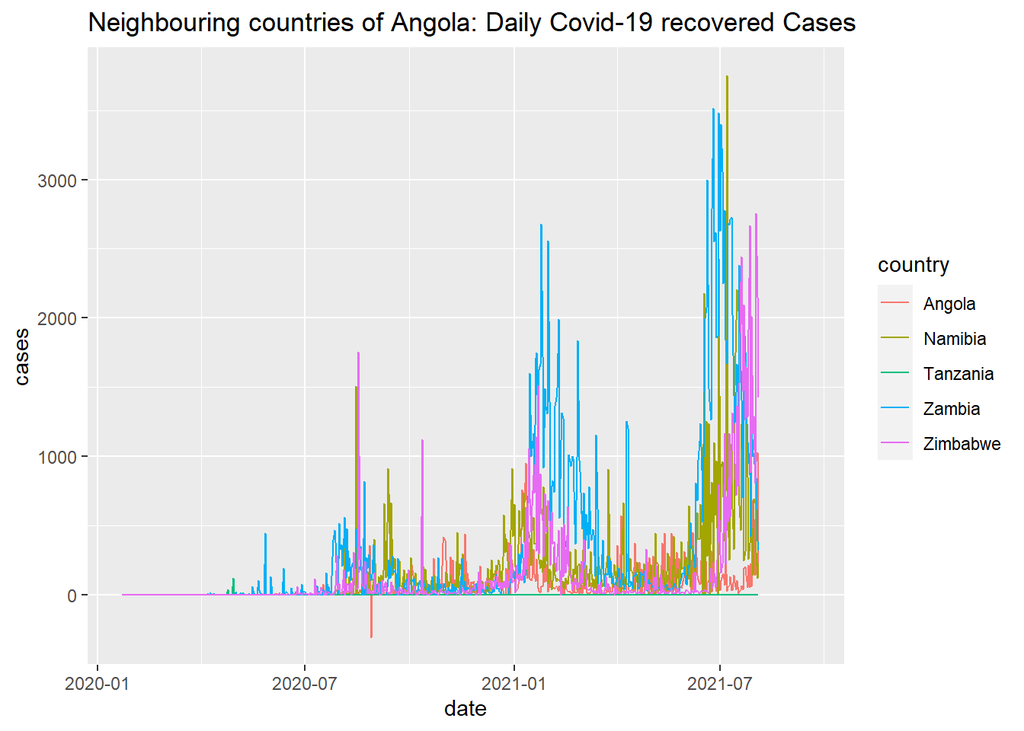

# 3.Discussion

# 4.Conclusions

The continent of Africa has larger number of countries which has poor health facilities and suffering from more than other countries. South Africa happened to start increasing the case in May, 2020. It was widely increasing much difficulties and no reducing. When it happened this way, it couldn’t control the deaths.

Therefore, all the countries have same responsible for prevent the virus in order to preventing spread to poor country. However, we can suggest that the Ministry of Health of Angola should pay special attention to the safety of healthcare professionals, as well as their mental wellbeing. Moreover, increasing the number of professionals in health units in Luanda, as well as increasing access and availability of personal protective equipment, especially for healthcare professionals, must be guaranteed for their protection and to increment the response capacity of the COVID-19 pandemic in Angola. Furthermore, studies on the mental health of healthcare professionals during the COVID-19 pandemic should be carried out in Angola, to help define strategies to improve the response capacity.

# 5.References

https://www.garda.com › crisis24 › news-alerts › angola…

https://ao.usembassy.gov › covid-19-information

https://www.worldometers.info › coronavirus › country

https://www.britannica.com › … › Countries of the World

https://en.wikipedia.org › wiki › Angola

https://www.britannica.com › … › Countries of the World

https://www.csis.org › analysis › angolan-government-r…